# GOcategoryStats

TODO: 1. Write a wrapper function that will take a set of query and a set of background genes, run the screening plots, perform the GO analysis, then produce screening plots for the top GO categories.

2. make this vignette make more sense

This vignette shows examples of exploring a set of genes using the GOcategoryStats package.

```r
library("devtools")
load_all("C:/Users/bigginsl/Documents/GOcategoryStats")
```

```
## Loading GOcategoryStats
```

## Processing the gmt and gtf files

```r
file_location <- "http://download.baderlab.org/EM_Genesets/current_release/Mouse/symbol/Mouse_GO_AllPathways_no_GO_iea_December_01_2018_symbol.gmt"

functional_categories <- process_GMT(file_location)


# file location, fread failed when tring to download directly from the url "ftp://ftp.ensembl.org/pub/release-94/gtf/mus_musculus/Mus_musculus.GRCm38.94.gtf.gz"
gtf_file <- "C:/Users/bigginsl/Downloads/Mus_musculus.GRCm38.94.gtf.gz"
gtf <- import_GTF(gtf_file)

gtf_processed <- parse_GTF_info(gtf)
```

We need some gene information that we’ll get from a gtf file

1. Check the genes against a background set. Produce the plots from gene screen.
2. overrepresentation test
3. explore the top GO category results - would be nice to have a brief summary of these - can we plot them neatly?

```r
head(genes_1)
```

```
## [1] "Ppbp"   "Gm1821" "Nrgn"   "Vwf"    "Myl9"   "Lrg1"
```

```r
head(bg_genes)
```

```
## [1] "U6"     "Xkr4"   "Gm1992" "U7"     "Rp1"    "Sox17"
```

```r
head(m_musculus)
```

|  | chr | type | start | end | info |
| --- | --- | --- | --- | --- | --- |
| 1 | 1 | gene | 3073253 | 3074322 | gene_id "ENSMUSG00000102693"; gene_version "1"; gene_name "4933401J01Rik"; gene_source "havana"; gene_biotype "TEC"; |
| 2 | 1 | gene | 3102016 | 3102125 | gene_id "ENSMUSG00000064842"; gene_version "1"; gene_name "Gm26206"; gene_source "ensembl"; gene_biotype "snRNA"; |
| 3 | 1 | gene | 3205901 | 3671498 | gene_id "ENSMUSG00000051951"; gene_version "5"; gene_name "Xkr4"; gene_source "ensembl_havana"; gene_biotype "protein_coding"; |
| 4 | 1 | gene | 3252757 | 3253236 | gene_id "ENSMUSG00000102851"; gene_version "1"; gene_name "Gm18956"; gene_source "havana"; gene_biotype "processed_pseudogene"; |
| 5 | 1 | gene | 3365731 | 3368549 | gene_id "ENSMUSG00000103377"; gene_version "1"; gene_name "Gm37180"; gene_source "havana"; gene_biotype "TEC"; |
| 6 | 1 | gene | 3375556 | 3377788 | gene_id "ENSMUSG00000104017"; gene_version "1"; gene_name "Gm37363"; gene_source "havana"; gene_biotype "TEC"; |

```r
gene_info <- parse_GTF_info(m_musculus)
head(gene_info)
```

|  | chr | type | start | end | info | gene_name | length |
| --- | --- | --- | --- | --- | --- | --- | --- |
| 1 | 1 | gene | 3073253 | 3074322 | gene_id "ENSMUSG00000102693"; gene_version "1"; gene_name "4933401J01Rik"; gene_source "havana"; gene_biotype "TEC"; | 4933401J01RIK | 1069 |
| 2 | 1 | gene | 3102016 | 3102125 | gene_id "ENSMUSG00000064842"; gene_version "1"; gene_name "Gm26206"; gene_source "ensembl"; gene_biotype "snRNA"; | GM26206 | 109 |
| 3 | 1 | gene | 3205901 | 3671498 | gene_id "ENSMUSG00000051951"; gene_version "5"; gene_name "Xkr4"; gene_source "ensembl_havana"; gene_biotype "protein_coding"; | XKR4 | 465597 |
| 4 | 1 | gene | 3252757 | 3253236 | gene_id "ENSMUSG00000102851"; gene_version "1"; gene_name "Gm18956"; gene_source "havana"; gene_biotype "processed_pseudogene"; | GM18956 | 479 |
| 5 | 1 | gene | 3365731 | 3368549 | gene_id "ENSMUSG00000103377"; gene_version "1"; gene_name "Gm37180"; gene_source "havana"; gene_biotype "TEC"; | GM37180 | 2818 |
| 6 | 1 | gene | 3375556 | 3377788 | gene_id "ENSMUSG00000104017"; gene_version "1"; gene_name "Gm37363"; gene_source "havana"; gene_biotype "TEC"; | GM37363 | 2232 |

```r
query_genes <- clean_text(genes_1)
bg_genes <- clean_text(bg_genes)

query_filt <- query_genes[query_genes %in% bg_genes]

#plot_lengths(genes_1, bg_genes, gene_info, in_background = TRUE){
#  query_genes <- clean_text(genes_1)
#  bg_genes    <- clean_text(bg_genes)

#  query_filt <- query_genes[query_genes %in% bg_genes]
#}
```

89 query genes were found in the background set. Those that did not match were removed.

## Comparing the properties of a set of genes of interest to a background set

Plot the length of all the genes.

```r
sum(!query_filt %in% gene_info$gene_name)
```

```
## [1] 0
```

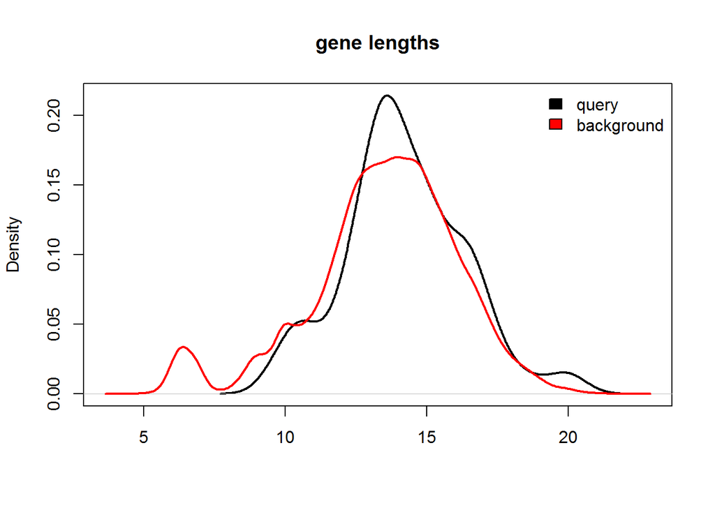

```r
# plot lengths
query_lengths <- get_lengths(query_filt, gene_info)
bg_lengths    <- get_lengths(bg_genes, gene_info)

my_plotting_data <- list(query = query_lengths, background = bg_lengths)
density_plot(my_plotting_data, log = TRUE, main = "gene lengths")
```

Plot which chromosome the genes are on.

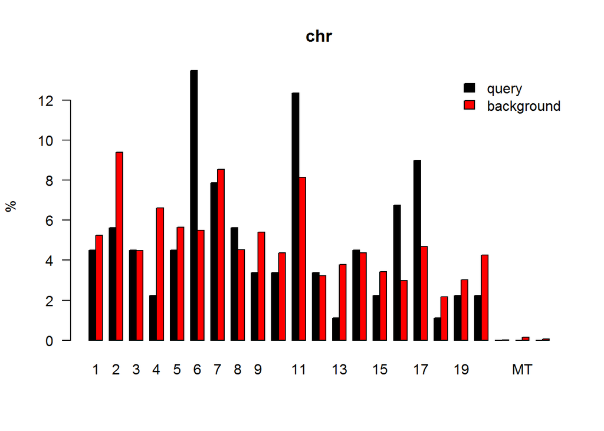

```r
query_chr <- get_chromosomes(query_filt, gene_info)
bg_chr    <- get_chromosomes(bg_genes, gene_info)

chr_list <- list(query = query_chr, background = bg_chr)

chr_proportions <- get_chr_percentage(chr_list)

bar_plot(chr_proportions, main = "chr")
```

Another way of viewing the same data

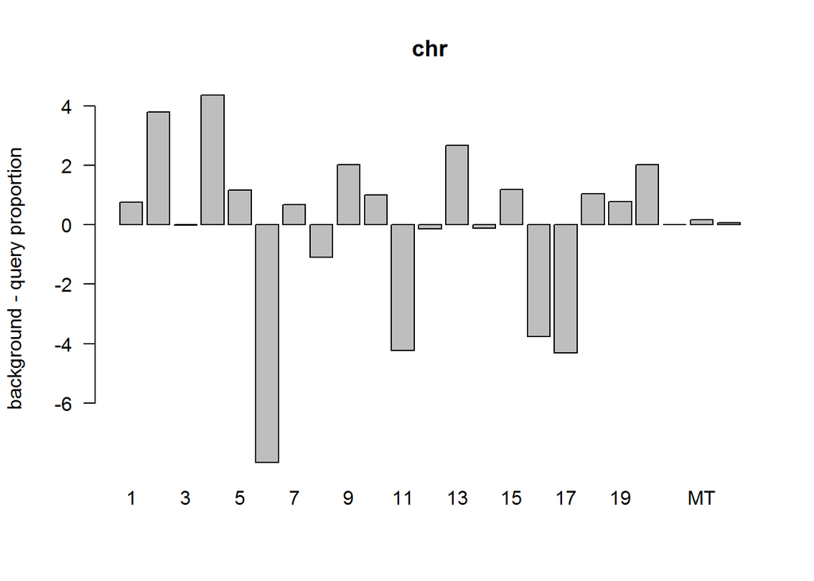

```r
bar_plot(chr_proportions, main = "chr", plot_differences = TRUE)
```

## Functional analysis

Do an overrepresentation test to see which gene ontology categories are overrepresented in the data

```r
# need to see how this gets processed - the all_go_categories file is too big,
# I'll have to produce a smaller version of it

go_results <- overrep_test(all_go_categories, genes_1, bg_genes)
head(go_results)
```

|  | query_in_category | bg_in_category | category_length | pval | adj_pval |
| --- | --- | --- | --- | --- | --- |
| EXTRACELLULAR REGION%GOCC%GO:0005576 | 53 | 3712 | 4023 | 3.439e-21 | 3.841e-18 |
| EXTRACELLULAR REGION PART%GOCC%GO:0044421 | 51 | 3628 | 3911 | 6.731e-20 | 3.759e-17 |
| PLATELET ACTIVATION, SIGNALING AND AGGREGATION%REACTOME%R-HSA-76002.2 | 20 | 259 | 262 | 1.157e-19 | 4.307e-17 |
| EXTRACELLULAR SPACE%GOCC%GO:0005615 | 49 | 3460 | 3735 | 4.558e-19 | 1.273e-16 |
| VESICLE%GOCC%GO:0031982 | 49 | 3584 | 3722 | 1.920e-18 | 4.289e-16 |
| HEMOSTASIS%REACTOME%R-HSA-109582.1 | 23 | 541 | 551 | 1.814e-17 | 3.377e-15 |

Have a look at the genes in the categories and see how the plots look.

Look up the genes from the category

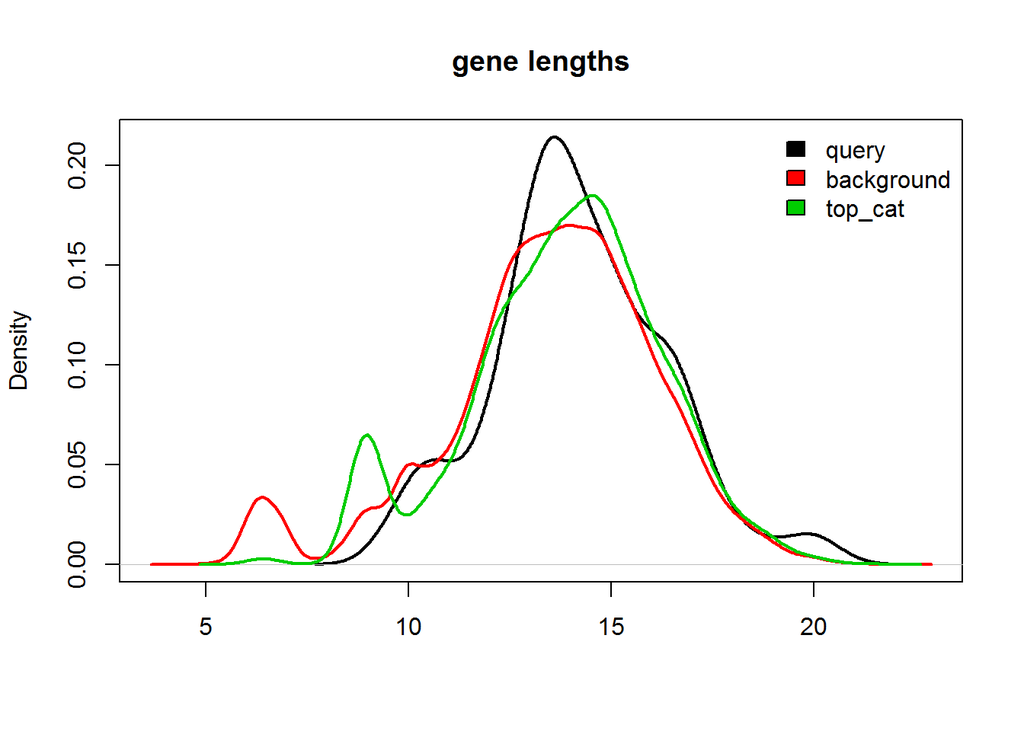

```r
# get the genes from the top category
top_cat <- get_GO_sets(rownames(go_results)[1], all_go_categories)
top_cat <- top_cat[[1]]

# plot lengths
query_lengths <- get_lengths(query_filt, gene_info)
bg_lengths <- get_lengths(bg_genes, gene_info)
top_cat_lengths <- get_lengths(top_cat, gene_info)

my_plotting_data <- list(query = query_lengths, background = bg_lengths, top_cat = top_cat_lengths)
density_plot(my_plotting_data, log = TRUE, main  = "gene lengths")
```

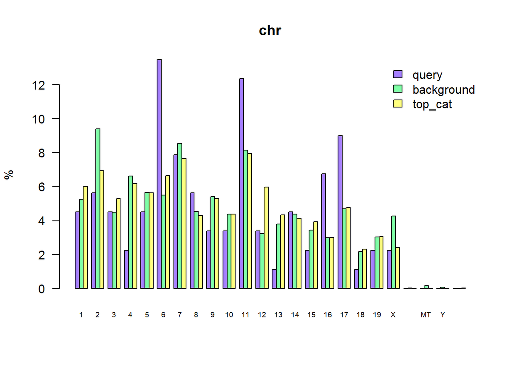

```r
query_chr <- get_chromosomes(query_filt, gene_info)
bg_chr <- get_chromosomes(bg_genes, gene_info)
top_cat_chr <- get_chromosomes(top_cat, gene_info)

chr_list <- list(query = query_chr, background = bg_chr, top_cat = top_cat_chr)

chr_proportions <- get_chr_percentage(chr_list)

bar_plot(chr_proportions, main = "chr", col = topo.colors(3, alpha = 0.5), cex_names = 0.6)
```

Look up the genes from the top 5 categories

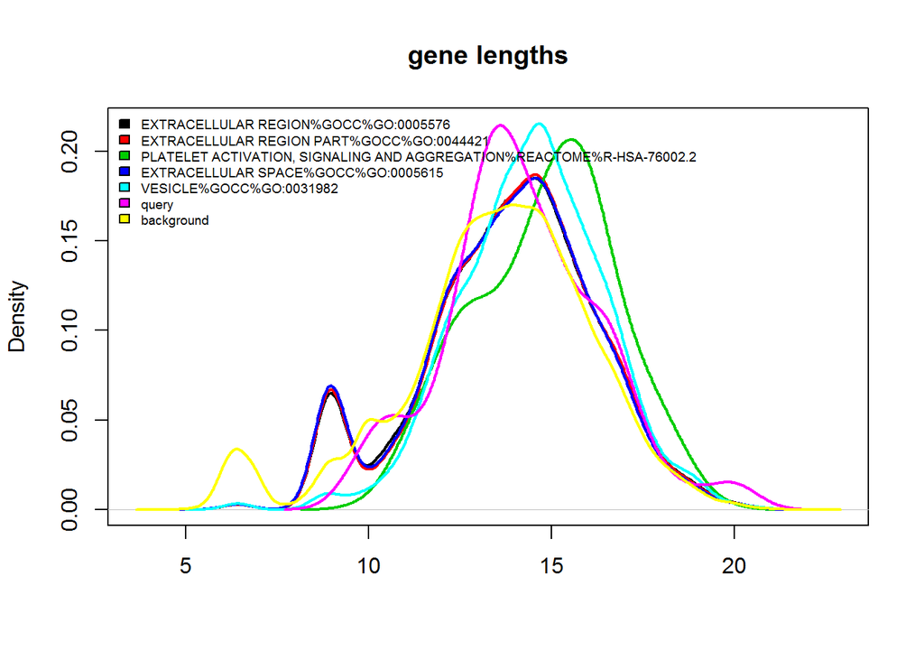

```r
selected_go <- rownames(go_results)[1:5]

# get the genes from the top category
top5_cat <- get_GO_sets(selected_go, all_go_categories)

# plot lengths
query_lengths <- get_lengths(query_filt, gene_info)
bg_lengths <- get_lengths(bg_genes, gene_info)

top5_cat_lengths <- lapply(top5_cat, get_lengths, gene_info)

my_plotting_data <- top5_cat_lengths
my_plotting_data[["query"]] <- query_lengths
my_plotting_data[["background"]] <- bg_lengths
density_plot(my_plotting_data, log = TRUE, main = "gene lengths", legend_cex = 0.6,
             legend_pos = "topleft")
```

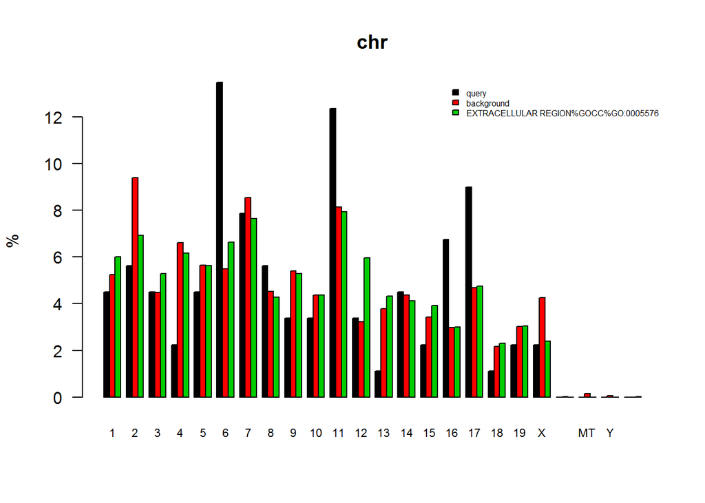

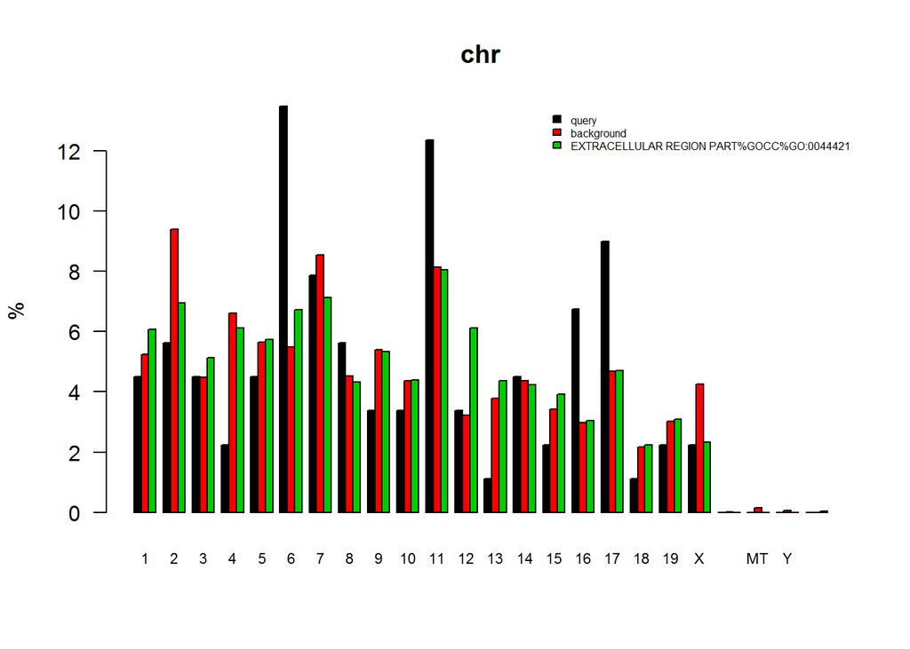

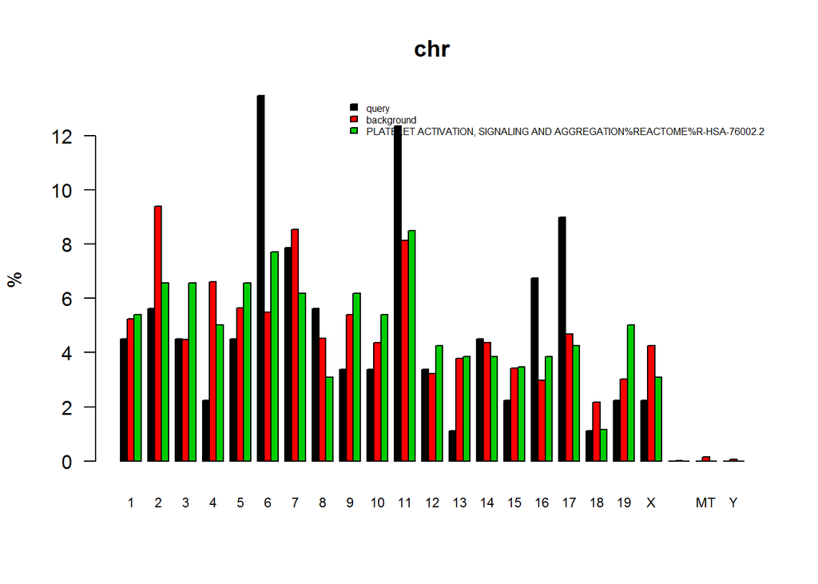

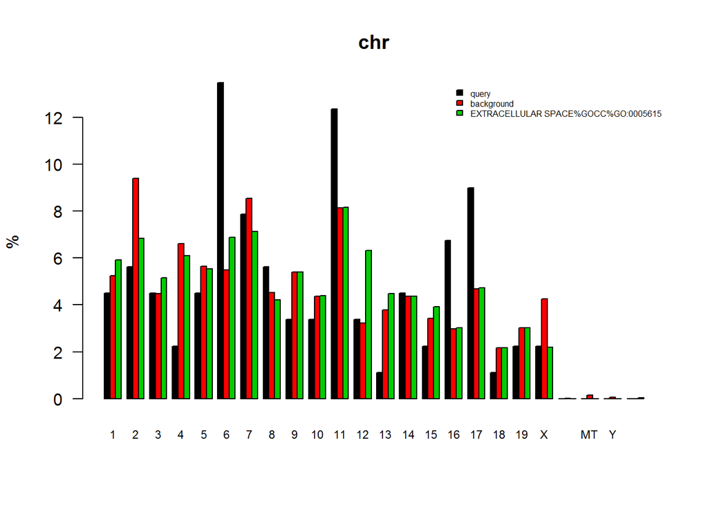

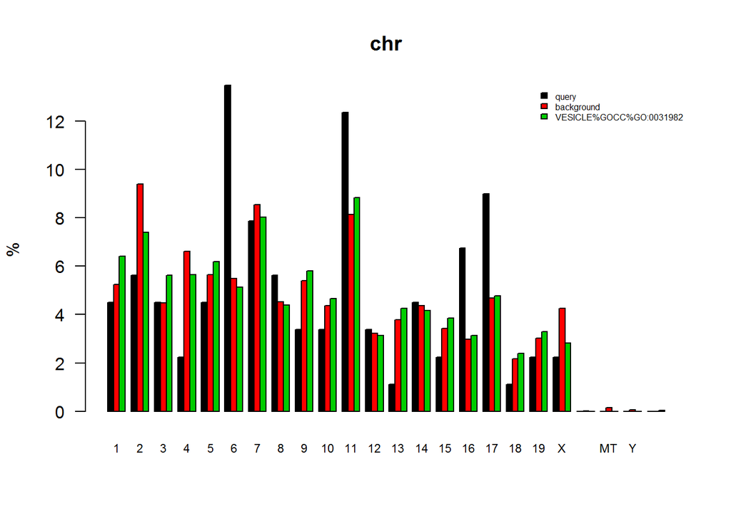

```r
query_chr <- get_chromosomes(query_filt, gene_info)
bg_chr <- get_chromosomes(bg_genes, gene_info)

chr_list <- list("query" = query_chr, "background" = bg_chr)

for (i in 1:5){
  chr_data <- chr_list
  chr_data[[names(top5_cat)[i]]] <- get_chromosomes(top5_cat[[i]], gene_info)
  chr_proportions <- get_chr_percentage(chr_data)

  bar_plot(chr_proportions, main = "chr", legend_cex = 0.5, cex_names = 0.7)
}
```